# HACKATHON-1 JANATAHACK MACHINE LEARNING FOR BANKING

## Problem Statement

Have you ever wondered how lenders use various factors such as credit score, annual income, the loan amount approved, tenure, debt-to-income ratio etc. and select your interest rates?

The process, defined as ‘risk-based pricing’, uses a sophisticated algorithm that leverages different determining factors of a loan applicant. Selection of significant factors will help develop a prediction algorithm which can estimate loan interest rates based on clients’ information. On one hand, knowing the factors will help consumers and borrowers to increase their credit worthiness and place themselves in a better position to negotiate for getting a lower interest rate. On the other hand, this will help lending companies to get an immediate fixed interest rate estimation based on clients information. Here, your goal is to use a training dataset to predict the loan rate category (1 / 2 / 3) that will be assigned to each loan in our test set.

You can use any combination of the features in the dataset to make your loan rate category predictions. Some features will be easier to use than others.

Variable

Definition

Loan_ID: A unique id for the loan.

Loan_Amount_Requested: The listed amount of the loan applied for by the borrower.

Length_Employed: Employment length in years

Home_Owner: The home ownersh p status provided by the borrower during registration. Values are: Rent, Own, Mortgage, Other.

Annual_Income: The annual income provided by the borrower during registration.

Income_Verified: Indicates if income was verified, not verified, or if the income source was verified

Purpose_Of_Loan: A category provided by the borrower for the loan request.

Debt_To_Income: A ratio calculated using the borrower’s total monthly debt payments on the total debt obligations, excluding mortgage and the requested loan, divided by the borrower’s self-reported monthly income.

Inquiries_Last_6Mo: The number of inquiries by creditors during the past 6 months.

Months_Since_Deliquency: The number of months since the borrower's last delinquency.

Number_Open_Accounts: The number of open credit lines in the borrower's credit file.

Total_Accounts: The total number of credit lines currently in the borrower's credit file

Gender: Gender(M/F)

Interest_Rate: Target Variable: Interest Rate category (1/2/3) of the loan application

## Importing necessary Libraries

```python
import os
import sys
import pandas as pd
import numpy as np
import matplotlib.pyplot as plt
%matplotlib inline
import seaborn as sns
import missingno as msno
from sklearn.preprocessing import LabelEncoder
from sklearn.model_selection import train_test_split
from sklearn.linear_model import LogisticRegression
from sklearn.tree import DecisionTreeClassifier
from sklearn.ensemble import RandomForestClassifier
from sklearn.naive_bayes import GaussianNB, BernoulliNB,MultinomialNB
from sklearn.metrics import accuracy_score,roc_auc_score,roc_curve,confusion_matrix
from sklearn.neighbors import KNeighborsClassifier
from sklearn.tree import plot_tree, export_text
from time import time
import sklearn.metrics as metrics
```

## Checking the current working directory

```python
os.getcwd()
```

```
'/Users/rohitsanam/ANALYTICS VIDHYA HACKATHONS'
```

## Changing the current working directory to the directory where the data resides

```python
os.chdir('/Users/rohitsanam/Downloads/ANALYTICS VIDHYA HACKATHONS')
```

## Reading the train data

```python
train = pd.read_csv('train_fNxu4vz.csv')
```

## Having a look at the top five rows of the train data

```python
train.head()
```

|  | Loan_ID | Loan_Amount_Requested | Length_Employed | Home_Owner | Annual_Income | Income_Verified | Purpose_Of_Loan | Debt_To_Income | Inquiries_Last_6Mo | Months_Since_Deliquency | Number_Open_Accounts | Total_Accounts | Gender | Interest_Rate |
| --- | --- | --- | --- | --- | --- | --- | --- | --- | --- | --- | --- | --- | --- | --- |
| 0 | 10000001 | 7,000 | < 1 year | Rent | 68000.0 | not verified | car | 18.37 | 0 | NaN | 9 | 14 | Female | 1 |
| 1 | 10000002 | 30,000 | 4 years | Mortgage | NaN | VERIFIED - income | debt_consolidation | 14.93 | 0 | 17.0 | 12 | 24 | Female | 3 |
| 2 | 10000003 | 24,725 | 7 years | Mortgage | 75566.4 | VERIFIED - income source | debt_consolidation | 15.88 | 0 | NaN | 12 | 16 | Male | 3 |
| 3 | 10000004 | 16,000 | < 1 year | NaN | 56160.0 | VERIFIED - income source | debt_consolidation | 14.34 | 3 | NaN | 16 | 22 | Male | 3 |
| 4 | 10000005 | 17,000 | 8 years | Own | 96000.0 | VERIFIED - income source | debt_consolidation | 22.17 | 1 | NaN | 19 | 30 | Female | 1 |

## having a look at the shape of the train dataset

```python
train.shape
```

```
(164309, 14)
```

## Reading the Test Data

```python
test = pd.read_csv('test_fjtUOL8.csv')
```

## Having a look at the top five rows of the test data

```python
test.head()
```

|  | Loan_ID | Loan_Amount_Requested | Length_Employed | Home_Owner | Annual_Income | Income_Verified | Purpose_Of_Loan | Debt_To_Income | Inquiries_Last_6Mo | Months_Since_Deliquency | Number_Open_Accounts | Total_Accounts | Gender |
| --- | --- | --- | --- | --- | --- | --- | --- | --- | --- | --- | --- | --- | --- |
| 0 | 10164310 | 27,500 | 10+ years | Mortgage | 129000.0 | VERIFIED - income | debt_consolidation | 12.87 | 0 | 68.0 | 10 | 37 | Male |
| 1 | 10164311 | 26,000 | 10+ years | NaN | 110000.0 | not verified | credit_card | 11.37 | 0 | NaN | 6 | 23 | Male |
| 2 | 10164312 | 6,075 | < 1 year | Rent | 75000.0 | VERIFIED - income | debt_consolidation | 6.83 | 2 | NaN | 5 | 20 | Male |
| 3 | 10164313 | 12,000 | 10+ years | Mortgage | 73000.0 | VERIFIED - income source | debt_consolidation | 7.76 | 0 | NaN | 6 | 8 | Male |
| 4 | 10164314 | 35,000 | < 1 year | Mortgage | 156000.0 | not verified | debt_consolidation | 9.62 | 0 | 26.0 | 9 | 21 | Male |

## Having a look at the shape of the test dataset

```python
test.shape
```

```
(109541, 13)
```

## Now lets Concatenate both the dataframes

```python
loan = pd.concat([train,test])
```

## Now lets have a look at the concatenated dataframe

```python
loan.head()
```

|  | Loan_ID | Loan_Amount_Requested | Length_Employed | Home_Owner | Annual_Income | Income_Verified | Purpose_Of_Loan | Debt_To_Income | Inquiries_Last_6Mo | Months_Since_Deliquency | Number_Open_Accounts | Total_Accounts | Gender | Interest_Rate |
| --- | --- | --- | --- | --- | --- | --- | --- | --- | --- | --- | --- | --- | --- | --- |
| 0 | 10000001 | 7,000 | < 1 year | Rent | 68000.0 | not verified | car | 18.37 | 0 | NaN | 9 | 14 | Female | 1.0 |
| 1 | 10000002 | 30,000 | 4 years | Mortgage | NaN | VERIFIED - income | debt_consolidation | 14.93 | 0 | 17.0 | 12 | 24 | Female | 3.0 |
| 2 | 10000003 | 24,725 | 7 years | Mortgage | 75566.4 | VERIFIED - income source | debt_consolidation | 15.88 | 0 | NaN | 12 | 16 | Male | 3.0 |
| 3 | 10000004 | 16,000 | < 1 year | NaN | 56160.0 | VERIFIED - income source | debt_consolidation | 14.34 | 3 | NaN | 16 | 22 | Male | 3.0 |
| 4 | 10000005 | 17,000 | 8 years | Own | 96000.0 | VERIFIED - income source | debt_consolidation | 22.17 | 1 | NaN | 19 | 30 | Female | 1.0 |

## Having a look at the shape of the concatenated dataframe

```python
loan.shape
```

```
(273850, 14)
```

## Checking unique values in each columns of categorical type

```python
for i in loan.columns:
    if loan[i].dtype == type(object):
        print(i,end=':')
        print('\n',loan[i].unique())
        print()
```

```
Loan_Amount_Requested:
 ['7,000' '30,000' '24,725' ... '32,700' '33,450' '34,425']

Length_Employed:
 ['< 1 year' '4 years' '7 years' '8 years' '2 years' '10+ years' '1 year'
 nan '6 years' '9 years' '3 years' '5 years']

Home_Owner:
 ['Rent' 'Mortgage' nan 'Own' 'Other' 'None']

Income_Verified:
 ['not verified' 'VERIFIED - income' 'VERIFIED - income source']

Purpose_Of_Loan:
 ['car' 'debt_consolidation' 'credit_card' 'home_improvement'
 'major_purchase' 'other' 'medical' 'small_business' 'moving' 'wedding'
 'vacation' 'house' 'educational' 'renewable_energy']

Gender:
 ['Female' 'Male']
```

## Having a look at the columns of the loan dataframe

```python
loan.columns
```

```
Index(['Loan_ID', 'Loan_Amount_Requested', 'Length_Employed', 'Home_Owner',
       'Annual_Income', 'Income_Verified', 'Purpose_Of_Loan', 'Debt_To_Income',
       'Inquiries_Last_6Mo', 'Months_Since_Deliquency', 'Number_Open_Accounts',
       'Total_Accounts', 'Gender', 'Interest_Rate'],
      dtype='object')
```

## Having a look at the summary statistics

```python
loan.describe()
```

|  | Loan_ID | Annual_Income | Debt_To_Income | Inquiries_Last_6Mo | Months_Since_Deliquency | Number_Open_Accounts | Total_Accounts | Interest_Rate |
| --- | --- | --- | --- | --- | --- | --- | --- | --- |
| count | 2.738500e+05 | 2.318500e+05 | 273850.000000 | 273850.000000 | 126612.000000 | 273850.000000 | 273850.000000 | 164309.000000 |
| mean | 1.013693e+07 | 7.339279e+04 | 17.215901 | 0.784543 | 34.103395 | 11.186025 | 25.067975 | 2.158951 |
| std | 7.905383e+04 | 5.852984e+04 | 7.845967 | 1.036816 | 21.750307 | 4.973663 | 11.589677 | 0.738364 |
| min | 1.000000e+07 | 3.000000e+03 | 0.000000 | 0.000000 | 0.000000 | 0.000000 | 2.000000 | 1.000000 |
| 25% | 1.006846e+07 | 4.500000e+04 | 11.360000 | 0.000000 | 16.000000 | 8.000000 | 17.000000 | 2.000000 |
| 50% | 1.013693e+07 | 6.300000e+04 | 16.850000 | 0.000000 | 31.000000 | 10.000000 | 23.000000 | 2.000000 |
| 75% | 1.020539e+07 | 8.900000e+04 | 22.780000 | 1.000000 | 49.000000 | 14.000000 | 32.000000 | 3.000000 |
| max | 1.027385e+07 | 7.500000e+06 | 39.990000 | 8.000000 | 180.000000 | 84.000000 | 156.000000 | 3.000000 |

## Missing Value Analysis

```python
loan.isnull().sum()
```

```
Loan_ID                         0
Loan_Amount_Requested           0
Length_Employed             12307
Home_Owner                  42060
Annual_Income               42000
Income_Verified                 0
Purpose_Of_Loan                 0
Debt_To_Income                  0
Inquiries_Last_6Mo              0
Months_Since_Deliquency    147238
Number_Open_Accounts            0
Total_Accounts                  0
Gender                          0
Interest_Rate              109541
dtype: int64
```

- From the above output I can say that there are missing valuesv in the following columns/features:
- Length_Employed
- Home_Owner
- Annual_Income
- Months_Since_Deliquency
- Interest_Rate

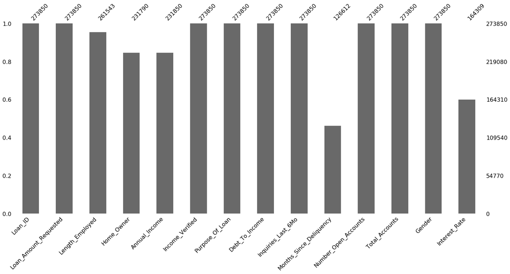

```python
msno.bar(loan)
```

## From the above plot I can say that there are missing values in the following columns/features:

- Length_Employed
- Home_Owner
- Annual_Income
- Months_Since_Deliquency
- Interest_Rate

## Checking the dtype using the info method

```python
loan.info()
```

```
<class 'pandas.core.frame.DataFrame'>
Int64Index: 273850 entries, 0 to 109540
Data columns (total 14 columns):
 #   Column                   Non-Null Count   Dtype
---  ------                   --------------   -----
 0   Loan_ID                  273850 non-null  int64
 1   Loan_Amount_Requested    273850 non-null  object
 2   Length_Employed          261543 non-null  object
 3   Home_Owner               231790 non-null  object
 4   Annual_Income            231850 non-null  float64
 5   Income_Verified          273850 non-null  object
 6   Purpose_Of_Loan          273850 non-null  object
 7   Debt_To_Income           273850 non-null  float64
 8   Inquiries_Last_6Mo       273850 non-null  int64
 9   Months_Since_Deliquency  126612 non-null  float64
 10  Number_Open_Accounts     273850 non-null  int64
 11  Total_Accounts           273850 non-null  int64
 12  Gender                   273850 non-null  object
 13  Interest_Rate            164309 non-null  float64
dtypes: float64(4), int64(4), object(6)
memory usage: 31.3+ MB
```

## Treating the missing values

```python
loan['Length_Employed'] = loan['Length_Employed'].fillna(loan['Length_Employed'].mode()[0])
```

```python
loan['Home_Owner'] = loan['Home_Owner'].fillna(loan['Home_Owner'].mode()[0])
```

```python
loan['Annual_Income'] = loan['Annual_Income'].fillna(loan['Annual_Income'].median())
```

```python
loan['Months_Since_Deliquency'] = loan['Months_Since_Deliquency'].fillna(loan['Months_Since_Deliquency'].median())
```

```python
loan['Interest_Rate'] = loan['Interest_Rate'].fillna(loan['Interest_Rate'].median())
```

## Now checking whether all the missing values are imputed or not

```python
loan.isnull().sum()
```

```
Loan_ID                    0
Loan_Amount_Requested      0
Length_Employed            0
Home_Owner                 0
Annual_Income              0
Income_Verified            0
Purpose_Of_Loan            0
Debt_To_Income             0
Inquiries_Last_6Mo         0
Months_Since_Deliquency    0
Number_Open_Accounts       0
Total_Accounts             0
Gender                     0
Interest_Rate              0
dtype: int64
```

## Now checking whether missing values have been impted or not graphically

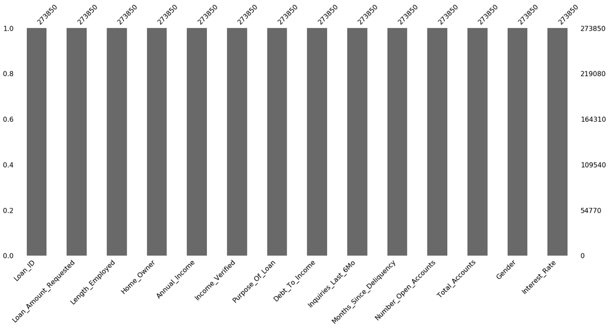

```python
msno.bar(loan)
```

- From the above output I can say that all the missing values are treated

## Univariate Analysis

```python
loan['Interest_Rate'].value_counts()
```

```
2.0    180121
3.0     59923
1.0     33806
Name: Interest_Rate, dtype: int64
```

## Now Lets have a look at the proportion of people under three different interest rate categories

```python
loan['Interest_Rate'].value_counts(normalize=True)
```

```
2.0    0.657736
3.0    0.218817
1.0    0.123447
Name: Interest_Rate, dtype: float64
```

## There are three different Interest Rates where 1.0 being the lowest rate and 3.0 being the highest rate and from the above output I can say that:

- There are 12.3% of the people who come under interest rate category 1.0
- There are 65.7% of the people who come under interest rate category 2.0
- There are 21.8% of the people who come under interest rate category 3.0

## countplot of the Target variable using sns

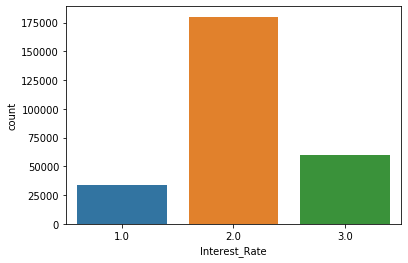

```python
sns.countplot(loan['Interest_Rate'])
```

- From the above plot I can say that there are more people who have taken a loan with the interest rate under the category 2.0

## Outlier Analysis

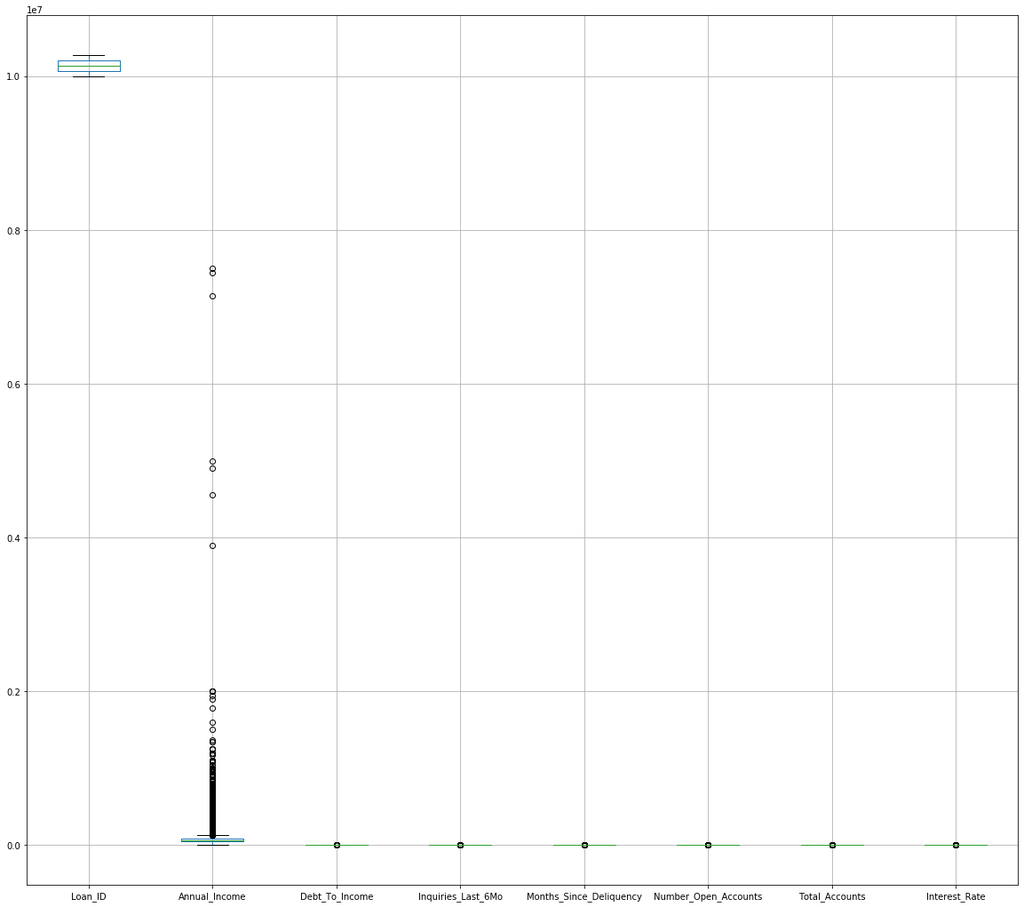

```python
plt.figure(figsize=(20,18))
loan.boxplot()
```

## From the above plot we can see that there are no outliers in the loan_ID feature

## Checking whether there is any relationship between the dependent feature and the other independent features

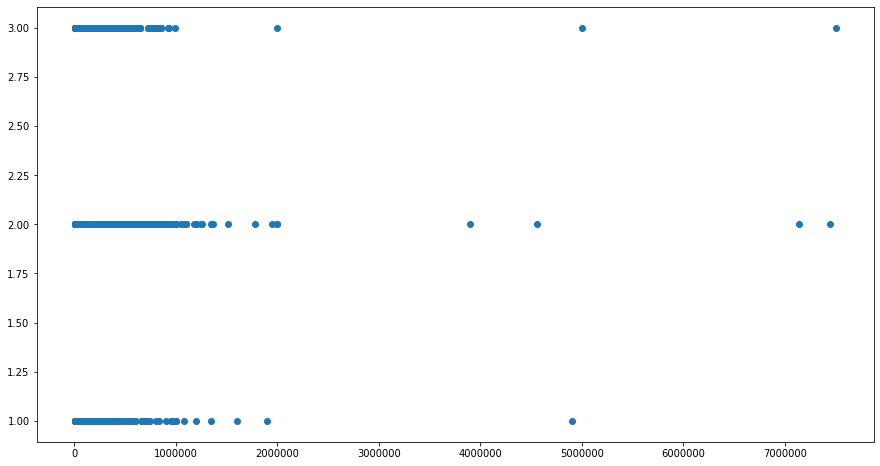

```python
plt.figure(figsize=(15,8))
plt.scatter(y=loan['Interest_Rate'],x=loan['Annual_Income'])
```

- From the above plot there is no correlation between Annual_Income and Interest_Rate

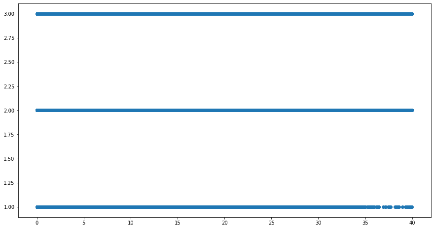

```python
plt.figure(figsize=(15,8))
plt.scatter(y=loan['Interest_Rate'],x=loan['Debt_To_Income'])
```

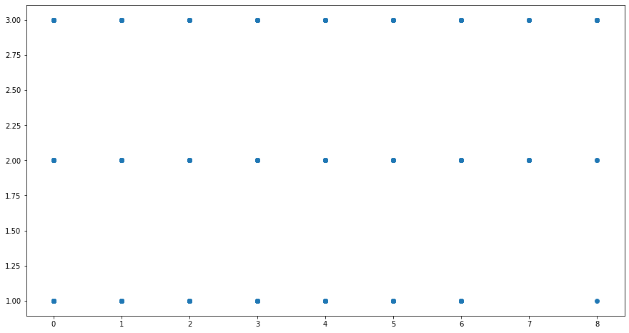

```python
plt.figure(figsize=(15,8))
plt.scatter(y=loan['Interest_Rate'],x=loan['Inquiries_Last_6Mo'])
```

- From the above plot there is no correlation between Inquiries_Last_6Mo and Interest_Rate

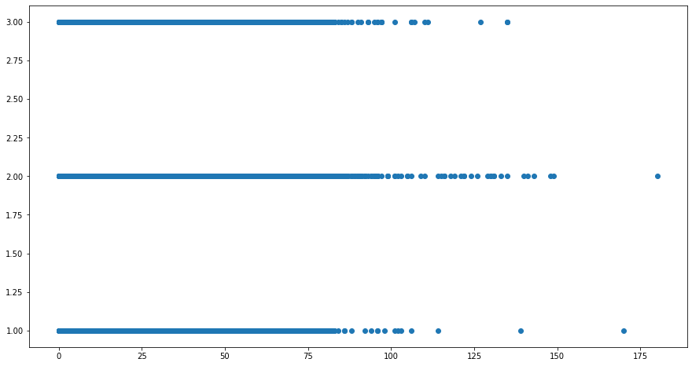

```python
plt.figure(figsize=(15,8))
plt.scatter(y=loan['Interest_Rate'],x=loan['Months_Since_Deliquency'])
```

- From the above plot there is no correlation between Months_Since_Deliquency and Interest_Rate

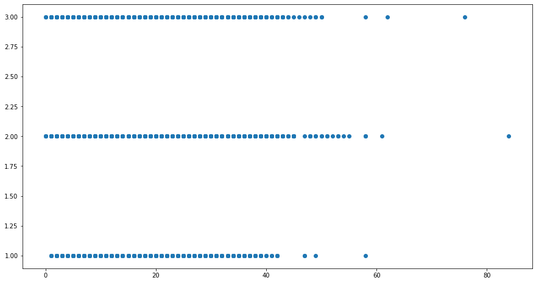

```python
plt.figure(figsize=(15,8))
plt.scatter(y=loan['Interest_Rate'],x=loan['Number_Open_Accounts'])
```

- From the above plot there is no correlation between Number_Open Accounts and Interest_Rate

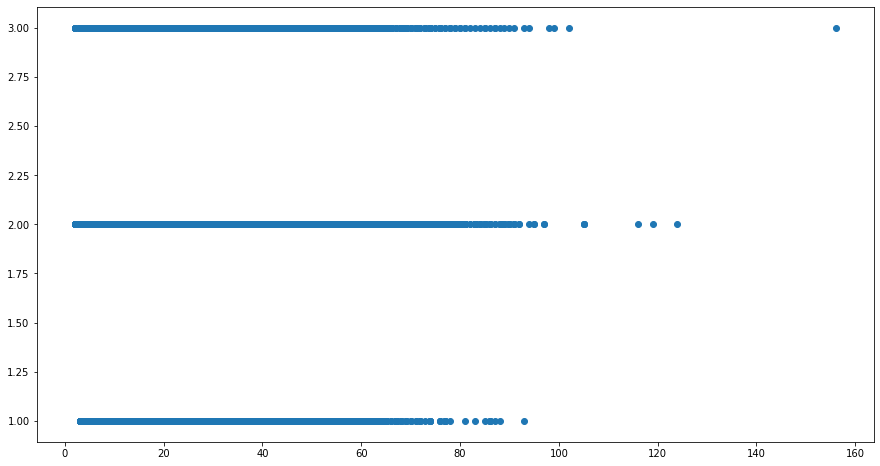

```python
plt.figure(figsize=(15,8))
plt.scatter(y=loan['Interest_Rate'],x=loan['Total_Accounts'])
```

- From the above plot there is no correlation between Total_Accounts and Interest_Rate
- As there is no correlation with dependent variable with any of the independent variables it is hard to decide whether to treat outliers or not

```python
le = LabelEncoder()
for cols in loan.columns:
    loan[cols]=le.fit_transform(loan[cols])

loan.head()
```

|  | Loan_ID | Loan_Amount_Requested | Length_Employed | Home_Owner | Annual_Income | Income_Verified | Purpose_Of_Loan | Debt_To_Income | Inquiries_Last_6Mo | Months_Since_Deliquency | Number_Open_Accounts | Total_Accounts | Gender | Interest_Rate |
| --- | --- | --- | --- | --- | --- | --- | --- | --- | --- | --- | --- | --- | --- | --- |
| 0 | 0 | 1195 | 10 | 4 | 10972 | 2 | 0 | 1836 | 0 | 31 | 9 | 12 | 0 | 0 |
| 1 | 1 | 911 | 4 | 0 | 9960 | 0 | 2 | 1492 | 0 | 17 | 12 | 22 | 0 | 2 |
| 2 | 2 | 668 | 7 | 0 | 12367 | 1 | 2 | 1587 | 0 | 31 | 12 | 14 | 1 | 2 |
| 3 | 3 | 279 | 10 | 0 | 8439 | 1 | 2 | 1433 | 3 | 31 | 16 | 20 | 1 | 2 |
| 4 | 4 | 319 | 8 | 3 | 15065 | 1 | 2 | 2216 | 1 | 31 | 19 | 28 | 0 | 0 |

## Splitting the data into dependent and Independent Varaiable

```python
X = loan.drop('Interest_Rate',axis=1)
y = loan['Interest_Rate']
```

## Train Test Split

```python
X_train,X_test,y_train,y_test = train_test_split(X,y,test_size=0.2,random_state=0)
```

```python
X_train.head()
```

|  | Loan_ID | Loan_Amount_Requested | Length_Employed | Home_Owner | Annual_Income | Income_Verified | Purpose_Of_Loan | Debt_To_Income | Inquiries_Last_6Mo | Months_Since_Deliquency | Number_Open_Accounts | Total_Accounts | Gender |
| --- | --- | --- | --- | --- | --- | --- | --- | --- | --- | --- | --- | --- | --- |
| 14271 | 178580 | 679 | 10 | 0 | 17233 | 2 | 4 | 1659 | 1 | 47 | 17 | 31 | 1 |
| 1472 | 165781 | 559 | 4 | 4 | 17374 | 1 | 2 | 1629 | 1 | 31 | 10 | 30 | 0 |
| 72013 | 72013 | 519 | 1 | 0 | 15649 | 1 | 2 | 2241 | 0 | 49 | 21 | 41 | 1 |
| 92694 | 257003 | 1155 | 6 | 4 | 755 | 2 | 1 | 2250 | 1 | 31 | 9 | 8 | 1 |
| 150190 | 150190 | 311 | 3 | 0 | 9960 | 1 | 2 | 3269 | 0 | 31 | 14 | 21 | 1 |

```python
X_test.head()
```

|  | Loan_ID | Loan_Amount_Requested | Length_Employed | Home_Owner | Annual_Income | Income_Verified | Purpose_Of_Loan | Debt_To_Income | Inquiries_Last_6Mo | Months_Since_Deliquency | Number_Open_Accounts | Total_Accounts | Gender |
| --- | --- | --- | --- | --- | --- | --- | --- | --- | --- | --- | --- | --- | --- |
| 96170 | 96170 | 64 | 8 | 3 | 9960 | 2 | 2 | 738 | 0 | 31 | 6 | 10 | 1 |
| 146122 | 146122 | 159 | 6 | 0 | 13666 | 1 | 1 | 513 | 0 | 21 | 4 | 5 | 0 |
| 33576 | 33576 | 1195 | 0 | 0 | 5851 | 0 | 1 | 1901 | 0 | 31 | 12 | 27 | 0 |
| 118817 | 118817 | 679 | 1 | 0 | 15853 | 1 | 2 | 1707 | 0 | 25 | 15 | 24 | 0 |
| 151958 | 151958 | 1237 | 8 | 4 | 1340 | 2 | 1 | 2797 | 0 | 31 | 15 | 16 | 0 |

```python
y_train.head()
```

```
14271     1
1472      1
72013     1
92694     1
150190    1
Name: Interest_Rate, dtype: int64
```

```python
y_test.head()
```

```
96170     1
146122    2
33576     0
118817    1
151958    2
Name: Interest_Rate, dtype: int64
```

```python
classifier_log = LogisticRegression()
model = classifier_log.fit(X_train,y_train)
```

```python
y_pred_log = classifier_log.predict(X_test)
```

```python
metrics.accuracy_score(y_test,y_pred_log)
```

```
0.6480007303268213
```

```python
y_pred_log
```

```
array([1, 1, 2, ..., 1, 1, 1])
```

```python
predictions_log = pd.DataFrame(y_pred_log)
```

```python
predictions_log
```

|  | 0 |
| --- | --- |
| 0 | 1 |
| 1 | 1 |
| 2 | 2 |
| 3 | 1 |
| 4 | 1 |
| ... | ... |
| 54765 | 1 |
| 54766 | 1 |
| 54767 | 1 |
| 54768 | 1 |
| 54769 | 1 |

54770 rows × 1 columns

```python
cm=confusion_matrix(y_test,y_pred_log)
print("Confusion Matrix is:", cm, sep='\n')
```

```
Confusion Matrix is:
[[  307  4719  1770]
 [  393 31634  4059]
 [  259  8079  3550]]
```

```python
dt = DecisionTreeClassifier()
model_dt = dt.fit(X_train,y_train)
y_pred_dt = dt.predict(X_test)
```

```python
metrics.accuracy_score(y_test,y_pred_dt)
```

```
0.6594120869088917
```

```python
y_pred_dt
```

```
array([1, 1, 1, ..., 1, 1, 1])
```

```python
predictions_dt = pd.DataFrame(y_pred_dt)
```

```python
predictions_dt
```

|  | 0 |
| --- | --- |
| 0 | 1 |
| 1 | 1 |
| 2 | 1 |
| 3 | 1 |
| 4 | 1 |
| ... | ... |
| 54765 | 1 |
| 54766 | 1 |
| 54767 | 1 |
| 54768 | 1 |
| 54769 | 1 |

54770 rows × 1 columns

```python
rf = RandomForestClassifier()
model = rf.fit(X_train,y_train)
y_pred_rf = rf.predict(X_test)
```

```python
metrics.accuracy_score(y_test,y_pred_rf)
```

```
0.710096768303816
```

```python
y_pred_rf
```

```
array([0, 1, 1, ..., 1, 1, 1])
```

```python
predictions_rf = pd.DataFrame(y_pred_rf)
```

```python
predictions_rf
```

|  | 0 |
| --- | --- |
| 0 | 0 |
| 1 | 1 |
| 2 | 1 |
| 3 | 1 |
| 4 | 1 |
| ... | ... |
| 54765 | 1 |
| 54766 | 2 |
| 54767 | 1 |
| 54768 | 1 |
| 54769 | 1 |

54770 rows × 1 columns

```python
gnb = GaussianNB()
```

```python
print("Start training...")
tStart = time()
gnb.fit(X_train, y_train)
tEnd = time()
print("Training time: ", round(tEnd-tStart, 3), "s")

# making predictions on the testing set
y_pred = gnb.predict(X_test)
print("Accuracy: ", metrics.accuracy_score(y_test, y_pred)*100)
```

```
Start training...
Training time:  0.104 s
Accuracy:  65.67829103523827
```

```python
cm=confusion_matrix(y_test,y_pred)
print("Confusion Matrix is:", cm, sep='\n')
```

```
Confusion Matrix is:
[[ 1176  4003  1617]
 [ 1388 30121  4577]
 [  789  6424  4675]]
```

```python
probs = gnb.predict_proba(X_test)
probs
```

```
array([[0.29374795, 0.47153298, 0.23471907],
       [0.14108525, 0.74673728, 0.11217747],
       [0.27904185, 0.34590607, 0.37505208],
       ...,
       [0.00536583, 0.98997135, 0.00466282],
       [0.14388048, 0.38509333, 0.47102619],
       [0.05780811, 0.4361787 , 0.50601318]])
```

```python
y_pred
```

```
array([1, 1, 2, ..., 1, 2, 2])
```

```python
len(y_pred)
```

```
54770
```

```python
X_test.shape
```

```
(54770, 13)
```

```python
knn = KNeighborsClassifier(n_neighbors=1)
```

```python
knn.fit(X_train,y_train)
```

```
KNeighborsClassifier(algorithm='auto', leaf_size=30, metric='minkowski',
                     metric_params=None, n_jobs=None, n_neighbors=1, p=2,
                     weights='uniform')
```

```python
pred = knn.predict(X_test)
```

```python
pred
```

```
array([1, 1, 1, ..., 1, 2, 2])
```

```python
len(pred)
```

```
54770
```

```python
print(confusion_matrix(y_test,pred))
```

```
[[ 1521  2952  2323]
 [ 2854 28170  5062]
 [ 2268  5044  4576]]
```

```python
metrics.accuracy_score(y_test,pred)
```

```
0.6256527295964944
```

```python
X_test.head()
```

|  | Loan_ID | Loan_Amount_Requested | Length_Employed | Home_Owner | Annual_Income | Income_Verified | Purpose_Of_Loan | Debt_To_Income | Inquiries_Last_6Mo | Months_Since_Deliquency | Number_Open_Accounts | Total_Accounts | Gender |
| --- | --- | --- | --- | --- | --- | --- | --- | --- | --- | --- | --- | --- | --- |
| 96170 | 96170 | 64 | 8 | 3 | 9960 | 2 | 2 | 738 | 0 | 31 | 6 | 10 | 1 |
| 146122 | 146122 | 159 | 6 | 0 | 13666 | 1 | 1 | 513 | 0 | 21 | 4 | 5 | 0 |
| 33576 | 33576 | 1195 | 0 | 0 | 5851 | 0 | 1 | 1901 | 0 | 31 | 12 | 27 | 0 |
| 118817 | 118817 | 679 | 1 | 0 | 15853 | 1 | 2 | 1707 | 0 | 25 | 15 | 24 | 0 |
| 151958 | 151958 | 1237 | 8 | 4 | 1340 | 2 | 1 | 2797 | 0 | 31 | 15 | 16 | 0 |

```python
predictions = pd.DataFrame({'Predictions':y_test,'Loan_Id':X_test['Loan_ID']})
```

```python
predictions.to_csv('Interest_Rate.csv')
```